# Summary of KVG validation progress

Alex Pate

2026-06-08

```
## [1] "2026-06-16 14:26:24 BST"
```

[output not shown]

# Calibration results

I apply IPACW weights as soon as anyone deviates from their treatment at baseline, with respect to statin use, or antihypertensive use. IPC weights are estimated by modelling the entire validation cohort together. IPAC weights are estimated using stratified models for those off treatment at baseline, antihypertensives at baseline, statins at baseline, or on both treatments at baseline. Predictors are the same for each model, but due to smaller sample sizes for the latter three cohorts, we do not include interaction terms between age and other predictors in these models. Sample size criteria of Riley et al., (DOI: 10.1002/sim.7992) are adhered to, to minimise risk of overfitting. This is all implemented in program p1_create_validation_data_and_assess_calibration.R.

These are the results from the three methods:

Smoothed-HT:

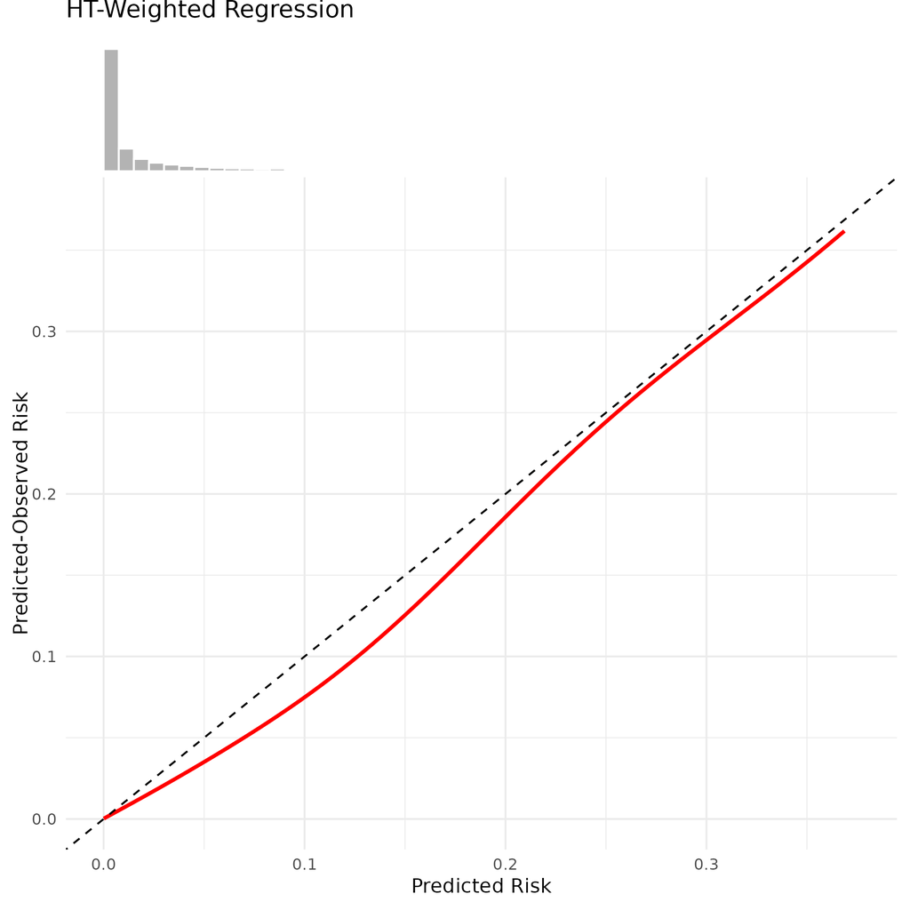

[figure not shown]

BLR-IPCW

Weighted pseudo-value:

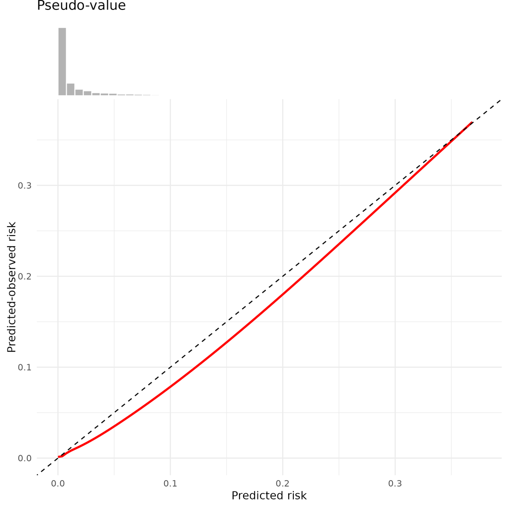

Table of calibration metrics:

```r
results_table <- readRDS("data/calibration_moderate_kvg_metric_table.rds")
knitr::kable(results_table)
```

| Method | ICI | E50 | E90 |
| --- | --- | --- | --- |
| BLR | 0.009 | 0.006 | 0.028 |
| Smoothed HT | 0.005 | 0.002 | 0.019 |
| Pseudo-value | 0.006 | 0.002 | 0.019 |

We find the model to be miscalibrated for all methods. I have triple checked the weights are being estimated correctly. Calibration is being assessed using the same function use in the simulated data example, meaning I do not think there can be errors there.

I believe there is such heavy artificial censoring, and likely unmeasured confounding between the artificial censoring mechanism and the outcome, that the assessment of calibration is likely to be biased. It’s impossible to say whether the model is really miscalibrated, or there is just a difference between the average conditional treatment effect taken from the literature, vs what can be recovered from the data using the IP weights.

A small exploration/summary of key variables in the data follows.

# Exploration of the data

Distribution of IPC weights:

```r
quantile(df_valid_realdata$ipcw_weight, p = c(0.5, 0.9, 0.95, 0.975, 0.99))
```

```
##       50%       90%       95%     97.5%       99%
##  1.803187  4.468223  6.225127  8.112632 10.522248
```

Distribution of IPAC weights:

```r
quantile(df_valid_realdata$ipacw_weight, p = c(0.5, 0.9, 0.95, 0.975, 0.99))
```

```
##      50%      90%      95%    97.5%      99%
## 1.081264 1.540479 1.923787 2.365701 3.113790
```

Distribution of combined weights:

```r
quantile(df_valid_realdata$comb_weight, p = c(0.5, 0.9, 0.95, 0.975, 0.99))
```

```
##       50%       90%       95%     97.5%       99%
##  2.223420  5.609712  7.706708  9.961084 12.990094
```

Summary of events per outcome group, in the original cohort, artificially censored cohort:

| med_status_statins | med_status_ah | mean_status_orig | sum_status_orig | sum_time_orig | mean_status_ac | sum_status_ac | sum_time_ac | orig_ac_time_ratio | orig_ac_indicator_ratio |
| --- | --- | --- | --- | --- | --- | --- | --- | --- | --- |
| 0 | 0 | 0.0195045 | 17622 | 5458.34513 | 0.0096548 | 8723 | 4655.77264 | 0.8529641 | 0.4950062 |
| 0 | 1 | 0.1277524 | 10049 | 604.36603 | 0.0651538 | 5125 | 323.13226 | 0.5346632 | 0.5100010 |
| 1 | 0 | 0.1093318 | 751 | 48.71951 | 0.0366866 | 252 | 21.27467 | 0.4366767 | 0.3355526 |
| 1 | 1 | 0.1641940 | 1804 | 81.18179 | 0.0946573 | 1040 | 53.32090 | 0.6568087 | 0.5764967 |

Furthermore, and most likely, there could be positivity issues, indicated by large weights. We are predicting the risk of a cardiovascular event if sustaining treatment for 10-years. There are a very small percentage of individuals who sustain treatment for this length of time, and do not have an event, meaning the risk set gets very small.

| med_status_statins | med_status_ah | total_sustained | prop_sustained |
| --- | --- | --- | --- |
| 0 | 0 | 171654 | 0.1899912 |
| 0 | 1 | 10675 | 0.1357107 |
| 1 | 0 | 456 | 0.0663852 |
| 1 | 1 | 1838 | 0.1672886 |

To explore this further, we will attempt to estimate the effect of sustaining statins or antihypertensives for 10-years (and other prediction intervals), using the same artificially censored cohort. We can use the same weights (or similar weights defined in the same way) to estimate risk under treatment, and risk untreated, and calculate a relative risk. If we are unable to get stable estimates of statin use and antihypertensive use, which are approximately in-line with the known effect of these interventions from trials, we know there issue an issue with the assumptions supporting analyses utilising ip weights in this way. These analyses are explored in programs p4.1, p4.2 and p4.3.3